# Penalized Linear Regression

## Data Structure

| Number of observations | 100 (Number of missings: 0) |
| --- | --- |
| Number of total variables | 7 |
| Number of used variables | 7 |

## Variable List

| Quantitative variable | x1, x2, x3, x4, x5, x6, y |
| --- | --- |

## Analysis Description

| Dependent variable | y |
| --- | --- |
| Explanatory variable | x1, x2, x3, x4, x5, x6 |
| Intercept included | TRUE |
| Standardization for explanatory variables | TRUE |
| Penalty method | Lasso |
| Candidate tuning parameter | Grid search (Number of grids : 100) |
| - Cross validation method | 10-fold cross validation |
| - Accuracy measure | Mean squared error |
| Validation method | Validation using training/test dataset |
| - Data splitting method for validataion | Randomly split by percent (training: 70%, test: 30%) |

## Results of Penalized Linear Regression

### Estimated values for Lambda

| Df | %Dev | Lambda |
| --- | --- | --- |
| 0 | 0 | 2.37 |
| 1 | 0.0696 | 2.16 |
| 1 | 0.127 | 1.97 |
| 1 | 0.175 | 1.8 |
| 2 | 0.227 | 1.64 |
| 3 | 0.318 | 1.49 |
| 3 | 0.423 | 1.36 |
| 3 | 0.51 | 1.24 |
| 3 | 0.583 | 1.13 |
| 3 | 0.643 | 1.03 |
| 3 | 0.693 | 0.936 |
| 3 | 0.734 | 0.853 |
| 4 | 0.771 | 0.777 |
| 4 | 0.81 | 0.708 |
| 4 | 0.842 | 0.645 |
| 4 | 0.869 | 0.588 |
| 4 | 0.891 | 0.536 |
| 4 | 0.91 | 0.488 |
| 4 | 0.925 | 0.445 |
| 4 | 0.938 | 0.405 |
| 4 | 0.948 | 0.369 |
| 4 | 0.957 | 0.337 |
| 4 | 0.964 | 0.307 |
| 4 | 0.97 | 0.279 |
| 4 | 0.975 | 0.255 |
| 4 | 0.98 | 0.232 |
| 4 | 0.983 | 0.211 |
| 4 | 0.986 | 0.193 |
| 4 | 0.988 | 0.175 |
| 4 | 0.99 | 0.16 |
| 4 | 0.992 | 0.146 |
| 4 | 0.993 | 0.133 |
| 4 | 0.994 | 0.121 |
| 4 | 0.995 | 0.11 |
| 4 | 0.996 | 0.1 |
| 4 | 0.997 | 0.0915 |
| 4 | 0.997 | 0.0834 |
| 4 | 0.998 | 0.076 |
| 4 | 0.998 | 0.0692 |
| 4 | 0.998 | 0.0631 |
| 4 | 0.999 | 0.0575 |
| 4 | 0.999 | 0.0523 |
| 4 | 0.999 | 0.0477 |

### Solution Path for the Best model

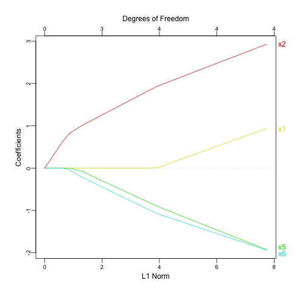

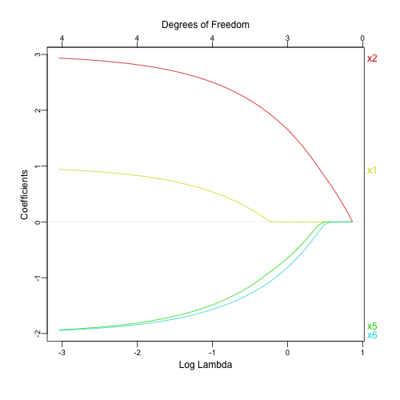

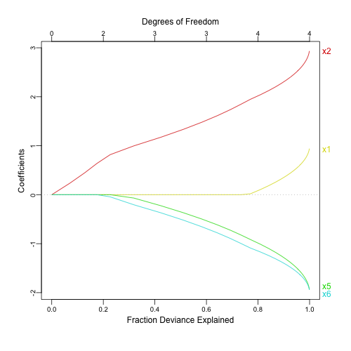

### Cross-Validation Plot

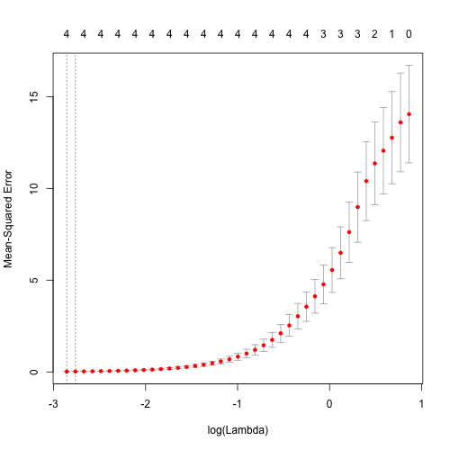

### Validation using training/test dataset

|  | N.non-missing observations | Percent | RMSE | MAE | Rsquared |
| --- | --- | --- | --- | --- | --- |
| Training | 70 | 70 | 0.1316 | 0.1052 | 0.9999 |
| Test | 30 | 30 | 0.1503 | 0.1117 | 1.0000 |

## Results of Linear Regression for the Best Model

|  | Estimate | SE | T-value | P-value | Lower bound of 95% CI | Upper bound of 95% CI |
| --- | --- | --- | --- | --- | --- | --- |
| (Intercept) | -9.122x10<sup>-05</sup> | 0.0013 | -0.0726 | 0.9423 | -0.0026 | 0.0024 |
| x1 | 1.0015 | 0.0013 | 751.6966 | 9.314x10<sup>-130</sup> | 0.9988 | 1.0042 |
| x2 | 2.9986 | 0.0014 | 2164.6246 | 1.298x10<sup>-159</sup> | 2.9958 | 3.0013 |
| x5 | -2.0006 | 0.0011 | -1751.0350 | 1.256x10<sup>-153</sup> | -2.0029 | -1.9983 |
| x6 | -1.9994 | 0.0012 | -1625.8274 | 1.561x10<sup>-151</sup> | -2.0018 | -1.9969 |

### Analysis-of-Variance Table

#### Model Effect (Goodness of Fit Test)

|  | SS | DF | MS | F-value | P-value | R2 | adj.R2 |
| --- | --- | --- | --- | --- | --- | --- | --- |
| Regression | 962.1153 | 4 | 240.5288 | 2223900.9303 | 3.948x10<sup>-166</sup> | 1 | 1 |
| Residual | 0.0070 | 65 | 0.0001 |  |  |  |  |
| Total | 962.1224 | 69 |  |  |  |  |  |

#### Variable Effect with Type III SS

|  | SS | DF | MS | F-value | P-value |
| --- | --- | --- | --- | --- | --- |
| (Intercept) | 5.708x10<sup>-07</sup> | 1 | 5.708x10<sup>-07</sup> | 0.0053 | 0.9423 |
| x1 | 61.1135 | 1 | 61.1135 | 565047.8355 | 9.314x10<sup>-130</sup> |
| x2 | 506.777 | 1 | 506.777 | 4685599.6173 | 1.298x10<sup>-159</sup> |
| x5 | 331.6205 | 1 | 331.6205 | 3066123.4090 | 1.256x10<sup>-153</sup> |
| x6 | 285.8911 | 1 | 285.8911 | 2643314.8441 | 1.561x10<sup>-151</sup> |

Note : In type III test, each row is the testing result for each effect after the other effect.

### Model Fitness Measurements

A model with a smaller value is better.

|  | Value | DF |
| --- | --- | --- |
| Deviance | 0.0070 | 65 |
| Pearson's chi-square | 0.0070 | 65 |
| -2*log-likelihood | -445.7715 | 6 |
| AIC | -433.7715 |  |
| BIC | -420.2805 |  |

## Used R Packages

Penalized linear regression : function 'cv.glmnet' of R package 'glmnet'

Solution path : function 'plot_glmnet' of R package 'plotmo'

Cross-validation plot : function 'plot.cv.glmnet' of R package 'glmnet'

Linear regression : function 'lm' of R package 'stats'

Confidence interval for regression coefficients : function 'confint' of R package 'stats'

Variance inflation factor (VIF) : function 'vif' of R package 'rms'

ANOVA table : function 'anova', 'anova' of R package 'stats', function 'anova', 'anova' of R package 'car'

Model fitness measurements : function 'residuals', 'logLik', 'AIC', 'BIC' of R package 'stats'

Goodness of fit test : function 'anova' of R package 'stats'

Fitted value : function 'fitted' of R package 'stats'

Predicted value : function 'predict' of R package 'stats'

Confidence & Prediction interval for fitted & predicted value : function 'predict' of R package 'stats'

Unstandardized residual : function 'residuals' of R package 'stats'

Standardized residual : function 'stdres' of R package 'MASS'

Studentized residual : function 'studres' of R package 'MASS'

Cook's distance : function 'cooks.distance' of R package 'stats'

Diagonals of hat matrix : function 'hatvalues' of R package 'stats'

All results other than those mentioned above were written with basic functions of R.

Analysis is finished at 2019-02-11 19:20:51. Rex : Penalized Linear Regression